# Ayudantía 8 - ML para Negocios

2 de noviembre del 2022

# Introducción

Bienvenid@s a la octava ayudantía de EAA3707 - Machine Learning para Negocios. En la ayudantía veremos:

1. Árboles de Decisión
2. Random Forests
3. Búsqueda iterativa de hiperparámetros
4. Discusión: Árboles de Regresión

Antes de comenzar, cargamos las librerías que utilizaremos durante la ayudantía.

```r
library(here)
library(beepr)
library(tidyverse)
library(tidymodels)
library(patchwork)
library(skimr)
library(corrplot)
library(rpart)
library(rpart.plot)
library(ranger)


# Para obtener resultados reproducibles
set.seed(219)
```

Ocupamos las siguientes librerías nuevas:

- `beepr`: permite emitir sonidos al terminar de ejecutar un comando. Útil cuando estamos ajustando modelos pesados.
- `skimr`: permite echar fácilmente un vistazo inicial a los datos.
- `rpart`: uno de los motores aceptados por `parsnip` para ajustar árboles de decisión.
- `ranger`: uno de los motores aceptados por `parsnip` para ajustar bosques aleatorios.

Les recuerdo los libros que les recomiendo para aprender de R:

- **Hands-On Programming with R**: disponible [acá](https://rstudio-education.github.io/hopr/). Útil para recordar cosas básicas de R.
- **Advanced R**: disponible [acá](https://adv-r.hadley.nz/). Para aprender R avanzado (realmente avanzado), si es que están interesados en entender cómo funciona R por detrás.
- **R for Data Science**: disponible [acá](https://r4ds.had.co.nz/). Bueno para aprender y aplicar Data Science de manera rápida, además de ser uno de los libros guía para aprender acerca de los paquetes de tidyverse.
- **RMarkdown Cookbook**: disponible [acá](https://bookdown.org/yihui/rmarkdown-cookbook/). Útil para aprender lo básico de RMarkdown.
- **RMarkdown: The Definitive Guide**: disponible [acá](https://bookdown.org/yihui/rmarkdown/). Útil para aprender cosas avanzadas de RMarkdown.
- **Tidy Modeling with R**: disponible [acá](https://www.tmwr.org/). Recomendado para aprender del ecosistema tidymodels. Tiene también un capítulo pequeño de tidyverse con lo justo y necesario.

# Árboles de Decisión

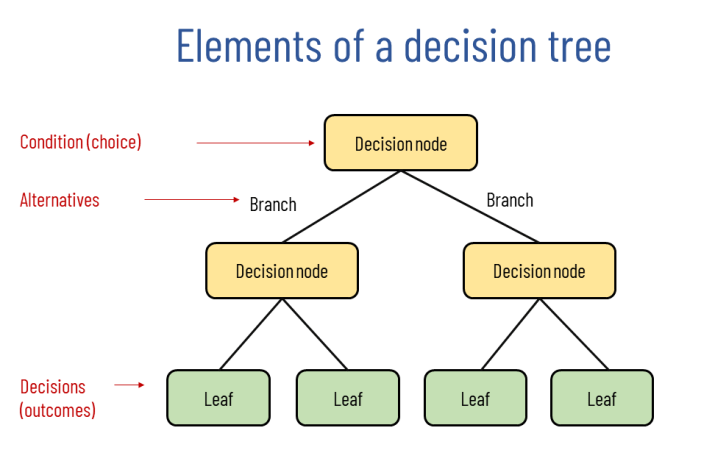

Árbol de Decisión y sus elementos. Créditos Yulia Kosarenko - Why Change Consulting

Los Árboles de Decisión corresponden a un modelo de clasificación, esto es, se dispone de un conjunto de datos previamente rotulados con la clase a la que pertenece cada observación. Una de las ventajas de este modelo es que es bastante simple y a la vez fácil de interpretar.

En particular, lo que hace es segmentar el espacio de predictores, de manera recursiva, y realizar una misma predicción para cada región final, correspondiente a la clase de mayor frecuencia.

**Nota**: Los modelos de árboles también pueden ser utilizados para regresión. Lo veremos más adelante.

Dentro de los árboles, tanto de decisión como de regresión, es importante la siguiente terminología:

- **Raíz**: Regla de decisión inicial del modelo
- **Ramas**: Caminos que sigue el árbol
- **Nodo interno**: Puntos intermedios en los cuales el árbol se divide de acuerdo a alguna regla de decisión
- **Nodo terminal u hoja**: Fin de una rama en la cual el árbol deja de dividirse. En este punto se realiza la clasificación.

## Criterios de división

¿Cómo segmentamos el espacio de predictores?. Una de las opciones más intuitivas es la de utilizar la tasa de clasificación incorrecta, pero se ha visto que empíricamente esta alternativa no funciona muy bien.

Así, entre las propuestas se encuentran dos que son bastante utilizadas: el Índice Gini y la Entropía.

### Índice Gini

Dado un conjunto de observaciones $D$ con $p_i$ la proporción de ellas que pertenecen a la i-ésima clase, se define el **Índice de Gini** como

$$\begin{equation*}
\text{Gini}(D) = 1 - \sum_{i=1}^m p_i^2
\end{equation*}$$

### Entropía

La idea de esta medida es que, si una clase es muy poco común, el saber que una observación dada pertenece a dicha clase entrega mucha información y, de manera equivalente, si una clase es común entonces la pertenencia entrega poca información. En particular, se tiene

$$\begin{equation*}
\text{Entropía}(D) = -\sum_{i=1}^m p_i \log_2 p_i
\end{equation*}$$
Luego, debemos elegir el atributo que tenga una mayor reducción esperada en entropía, esto es,

$$\text{Gain}(S, A) = \text{Entropía}(S) - \sum_{v \in
A}\frac{|S_v|}{|S|}\text{Entropía}(S_r)$$

donde $S$ es el set original, $A$ es algún atributo y $S_r$ es la entropía del sub-grupo $r$ de $A$.

## Overfitting

Uno de los problemas de los árboles de decisión es que fácilmente podemos caer en el problema de overfitting si no nos cuidamos de ajustar un modelo con muchas ramificaciones. Para cuidarnos de lo anterior, existen varias opciones:

- **Poda de un árbol**: Para esto, se introduce un parámetro de complejidad, comúnmente denotado por $\alpha$ o $Cp$. Este parámetro controla el tamaño total del árbol, penalizando por el número total de nodos finales.
- **Tree Depth**: Controla la máxima profundidad del árbol.
- **Mínimo n**: Mínimo número de puntos en un nodo requeridos para que el nodo se vuelva a dividir.

# Random Forests

La idea de los Bosques Aleatorios es bastante simple, y es que se unen muchos árboles de decisión. Para esto, se entrenan $L$ árboles de decisión, usando en cada caso $N$ datos de entrenamiento, normalmente muestreados con reemplazo. Finalmente, la clasificación está dada por la predicción más común entre los $L$ árboles resultantes (majority vote)

Además, en cada división estos árboles consideran solo un conjunto $m < M$ de atributos disponibles, elegidos de manera aleatoria.

# Búsqueda Iterativa

En las ayudantías anteriores hemos visto dos maneras de búsqueda de hiperparámetros, ambas de la categoría de grillas: grillas regulares y grillas aleatorias.

En esta ayudantía presentaremos una forma diferente de buscar estos valores y es a través de búsqueda iterativa. Estos algoritmos consideran diferentes puntos de partida y va considerando valores cercanos que vayan optimizando la métrica deseada. Así, la diferencia con las grillas regulares es que no fija los valores a buscar al principio del algoritmo, si no que los va considerando en cada iteración.

Podemos ver la diferencia de los tres algoritmos a continuación.

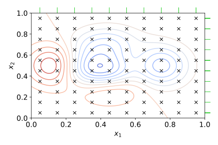

Búsqueda en grillas regulares. Créditos https://en.wikipedia.org/wiki/Hyperparameter_optimization

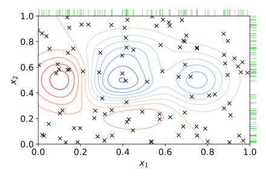

Búsqueda en grillas aleatorias. Créditos https://en.wikipedia.org/wiki/Hyperparameter_optimization

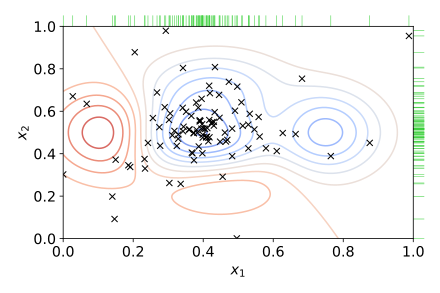

Búsqueda iterativa. Créditos https://en.wikipedia.org/wiki/Hyperparameter_optimization

Es importante notar que uno de los problemas de este algoritmo es que no podemos asegurar la convergencia a un mínimo/máximo global, sino que solo a locales. De todas maneras, una de las formas de aliviar este problema es considerar diferentes puntos de partida en el espacio de búsqueda.

En particular, tidymodels nos deja realizar optimización bayesiana a través de la función `tune_bayes`.

# Ejemplo: Clasificación de precios de teléfonos

[figure not shown]

Créditos: The Verge

Harto del número reducido de empresas de teléfonos celulares, usted decide iniciar su propia compañía que logre competir con las diferentes empresas globales importantes.

Uno de los problemas es poder estimar el precio de los celulares que producirá, para lo cual decide recolectar datos de diferentes celulares y el rango de precios al que pertenecen. Utilizando estos datos, desea entrenar un modelo de clasificación que le permita definir un rango de precios para sus futuros productos.

Estos datos se encuentran en la base de datos `mobile_price.csv`. Entre las variables se encuentran:

- **battery_power**: energía total que puede almacenar, en mAh
- **blue**: tiene bluetooth o no
- **clock_speed**: velocidad del microproceasador
- **dual_sim**: tiene soporte para dual sim o no
- **fc**: megapixeles de la cámara frontal (0 si no tiene cámara frontal)
- **four_g**: si tiene o no 4G
- **int_memory**: memoria interna en GB
- **pc**: megapixeles de la cámara principal
- **px_height**: resolución a lo alto
- **px_widht**: resolución a lo ancho
- **ram**: memoria RAM del dispositivo en megabytes
- **sc_h**: alto de la pantalla en centímetros
- **sc_w**: ancho de la pantalla en centímetros
- **price_range**: variable respuesta. Toma los valores 0 (bajo costo), 1 (costo medio), 2 (costo alto) y 3 (costo muy alto)

## Análisis exploratorio

Importemos en primer lugar nuestros datos y demos un primer vistazo inicial.

```r
# Cargamos los datos
mobile_prices_unclean <- readr::read_csv(here("Ayudantía 8", "mobile_price.csv"),
                                         show_col_types = FALSE)

# Damos un vistazo
skimr::skim(mobile_prices_unclean)
```

Data summary

| Name | mobile_prices_unclean |
| --- | --- |
| Number of rows | 2000 |
| Number of columns | 21 |
| _______________________ |  |
| Column type frequency: |  |
| numeric | 21 |
| ________________________ |  |
| Group variables | None |

**Variable type: numeric**

| skim_variable | n_missing | complete_rate | mean | sd | p0 | p25 | p50 | p75 | p100 | hist |
| --- | --- | --- | --- | --- | --- | --- | --- | --- | --- | --- |
| battery_power | 0 | 1 | 1238.52 | 439.42 | 501.0 | 851.75 | 1226.0 | 1615.25 | 1998 | ▇▇▇▇▇ |
| blue | 0 | 1 | 0.50 | 0.50 | 0.0 | 0.00 | 0.0 | 1.00 | 1 | ▇▁▁▁▇ |
| clock_speed | 0 | 1 | 1.52 | 0.82 | 0.5 | 0.70 | 1.5 | 2.20 | 3 | ▇▃▃▃▃ |
| dual_sim | 0 | 1 | 0.51 | 0.50 | 0.0 | 0.00 | 1.0 | 1.00 | 1 | ▇▁▁▁▇ |
| fc | 0 | 1 | 4.31 | 4.34 | 0.0 | 1.00 | 3.0 | 7.00 | 19 | ▇▃▂▁▁ |
| four_g | 0 | 1 | 0.52 | 0.50 | 0.0 | 0.00 | 1.0 | 1.00 | 1 | ▇▁▁▁▇ |
| int_memory | 0 | 1 | 32.05 | 18.15 | 2.0 | 16.00 | 32.0 | 48.00 | 64 | ▇▆▇▇▇ |
| m_dep | 0 | 1 | 0.50 | 0.29 | 0.1 | 0.20 | 0.5 | 0.80 | 1 | ▇▆▆▆▅ |
| mobile_wt | 0 | 1 | 140.25 | 35.40 | 80.0 | 109.00 | 141.0 | 170.00 | 200 | ▇▇▇▇▇ |
| n_cores | 0 | 1 | 4.52 | 2.29 | 1.0 | 3.00 | 4.0 | 7.00 | 8 | ▇▃▇▃▇ |
| pc | 0 | 1 | 9.92 | 6.06 | 0.0 | 5.00 | 10.0 | 15.00 | 20 | ▇▆▆▆▆ |
| px_height | 0 | 1 | 645.11 | 443.78 | 0.0 | 282.75 | 564.0 | 947.25 | 1960 | ▇▇▅▂▁ |
| px_width | 0 | 1 | 1251.52 | 432.20 | 500.0 | 874.75 | 1247.0 | 1633.00 | 1998 | ▇▇▇▇▇ |
| ram | 0 | 1 | 2124.21 | 1084.73 | 256.0 | 1207.50 | 2146.5 | 3064.50 | 3998 | ▇▇▇▇▇ |
| sc_h | 0 | 1 | 12.31 | 4.21 | 5.0 | 9.00 | 12.0 | 16.00 | 19 | ▆▇▇▇▇ |
| sc_w | 0 | 1 | 5.77 | 4.36 | 0.0 | 2.00 | 5.0 | 9.00 | 18 | ▇▆▃▂▁ |
| talk_time | 0 | 1 | 11.01 | 5.46 | 2.0 | 6.00 | 11.0 | 16.00 | 20 | ▇▇▆▇▇ |
| three_g | 0 | 1 | 0.76 | 0.43 | 0.0 | 1.00 | 1.0 | 1.00 | 1 | ▂▁▁▁▇ |
| touch_screen | 0 | 1 | 0.50 | 0.50 | 0.0 | 0.00 | 1.0 | 1.00 | 1 | ▇▁▁▁▇ |
| wifi | 0 | 1 | 0.51 | 0.50 | 0.0 | 0.00 | 1.0 | 1.00 | 1 | ▇▁▁▁▇ |
| price_range | 0 | 1 | 1.50 | 1.12 | 0.0 | 0.75 | 1.5 | 2.25 | 3 | ▇▇▁▇▇ |

Notamos en particular que algunas variables que deberían ser factor aparecen como numéricas, así que debemos cambiarlas.

```r
mobile_prices <- mobile_prices_unclean %>%
  dplyr::mutate(blue = factor(blue, levels=c(1, 0), labels=c("Yes", "No")),
                dual_sim = factor(dual_sim, levels=c(1, 0), labels=c("Yes", "No")),
                four_g = factor(four_g, levels=c(1, 0), labels=c("Yes", "No")),
                three_g = factor(three_g, levels=c(1, 0), labels=c("Yes", "No")),
                touch_screen = factor(touch_screen, levels=c(1, 0),
                                      labels=c("Yes", "No")),
                wifi = factor(wifi, levels=c(1, 0), labels=c("Yes", "No")),
                price_range = factor(price_range, levels=c(0, 1, 2, 3),
                                     labels=c("Low", "Medium", "High", "Very High"),
                                     ordered = TRUE))

skimr::skim(mobile_prices)
```

Data summary

| Name | mobile_prices |
| --- | --- |
| Number of rows | 2000 |
| Number of columns | 21 |
| _______________________ |  |
| Column type frequency: |  |
| factor | 7 |
| numeric | 14 |
| ________________________ |  |
| Group variables | None |

**Variable type: factor**

| skim_variable | n_missing | complete_rate | ordered | n_unique | top_counts |
| --- | --- | --- | --- | --- | --- |
| blue | 0 | 1 | FALSE | 2 | No: 1010, Yes: 990 |
| dual_sim | 0 | 1 | FALSE | 2 | Yes: 1019, No: 981 |
| four_g | 0 | 1 | FALSE | 2 | Yes: 1043, No: 957 |
| three_g | 0 | 1 | FALSE | 2 | Yes: 1523, No: 477 |
| touch_screen | 0 | 1 | FALSE | 2 | Yes: 1006, No: 994 |
| wifi | 0 | 1 | FALSE | 2 | Yes: 1014, No: 986 |
| price_range | 0 | 1 | TRUE | 4 | Low: 500, Med: 500, Hig: 500, Ver: 500 |

**Variable type: numeric**

| skim_variable | n_missing | complete_rate | mean | sd | p0 | p25 | p50 | p75 | p100 | hist |
| --- | --- | --- | --- | --- | --- | --- | --- | --- | --- | --- |
| battery_power | 0 | 1 | 1238.52 | 439.42 | 501.0 | 851.75 | 1226.0 | 1615.25 | 1998 | ▇▇▇▇▇ |
| clock_speed | 0 | 1 | 1.52 | 0.82 | 0.5 | 0.70 | 1.5 | 2.20 | 3 | ▇▃▃▃▃ |
| fc | 0 | 1 | 4.31 | 4.34 | 0.0 | 1.00 | 3.0 | 7.00 | 19 | ▇▃▂▁▁ |
| int_memory | 0 | 1 | 32.05 | 18.15 | 2.0 | 16.00 | 32.0 | 48.00 | 64 | ▇▆▇▇▇ |
| m_dep | 0 | 1 | 0.50 | 0.29 | 0.1 | 0.20 | 0.5 | 0.80 | 1 | ▇▆▆▆▅ |
| mobile_wt | 0 | 1 | 140.25 | 35.40 | 80.0 | 109.00 | 141.0 | 170.00 | 200 | ▇▇▇▇▇ |
| n_cores | 0 | 1 | 4.52 | 2.29 | 1.0 | 3.00 | 4.0 | 7.00 | 8 | ▇▃▇▃▇ |
| pc | 0 | 1 | 9.92 | 6.06 | 0.0 | 5.00 | 10.0 | 15.00 | 20 | ▇▆▆▆▆ |
| px_height | 0 | 1 | 645.11 | 443.78 | 0.0 | 282.75 | 564.0 | 947.25 | 1960 | ▇▇▅▂▁ |
| px_width | 0 | 1 | 1251.52 | 432.20 | 500.0 | 874.75 | 1247.0 | 1633.00 | 1998 | ▇▇▇▇▇ |
| ram | 0 | 1 | 2124.21 | 1084.73 | 256.0 | 1207.50 | 2146.5 | 3064.50 | 3998 | ▇▇▇▇▇ |
| sc_h | 0 | 1 | 12.31 | 4.21 | 5.0 | 9.00 | 12.0 | 16.00 | 19 | ▆▇▇▇▇ |
| sc_w | 0 | 1 | 5.77 | 4.36 | 0.0 | 2.00 | 5.0 | 9.00 | 18 | ▇▆▃▂▁ |
| talk_time | 0 | 1 | 11.01 | 5.46 | 2.0 | 6.00 | 11.0 | 16.00 | 20 | ▇▇▆▇▇ |

Así, tenemos 14 variables numéricas y 7 categóricas, incluyendo la variable respuesta.

Como análisis exploratorio, podemos ver en primer lugar la correlación entre las variables númericas presentes en la base de datos.

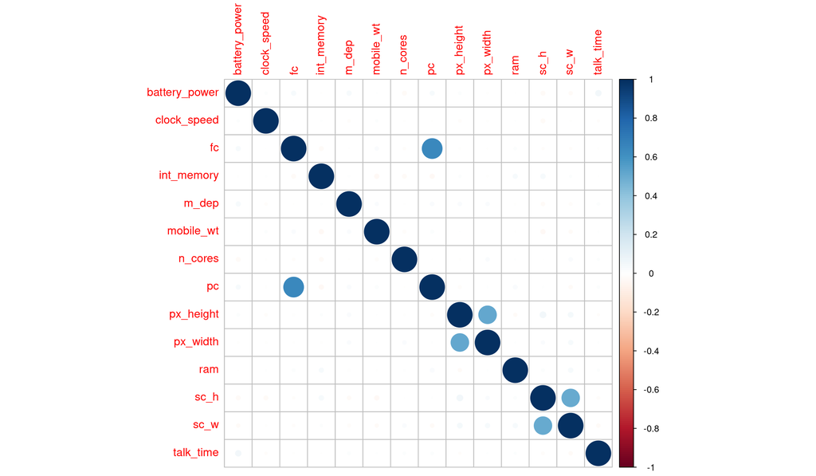

Notamos que existe una baja correlación excepto entre variables que intuitivamente sí deberían estar correlacionadas entre sí.

Por otro lado, podemos elegir dos variables al azar y realizar boxplots para ver si existen relaciones entre alguna de ellas con el rango de precios. Para este ejemplo, tomé la velocidad del procesador y la memoria RAM.

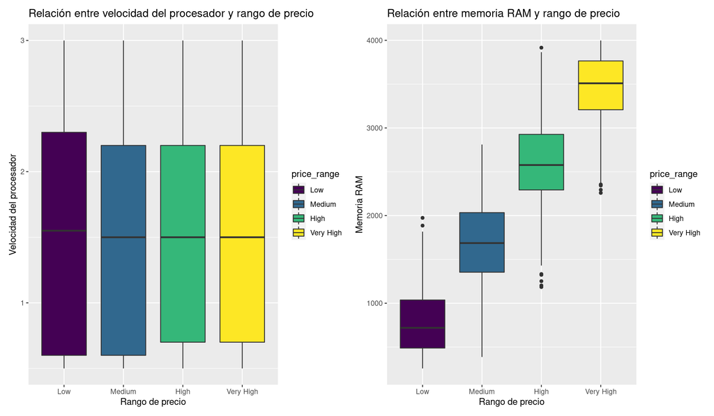

Notamos que pareciera no existir una relación con la primera variable, pero sí una clara relación positiva entre la memoria RAM con el precio.

## Modelamiento: Árboles de Decisión

Realizamos los pasos iniciales típicos. En este caso, debemos usar `decision_tree` al momento de definir el modelo, el cual acepta tres hiperparámetros: costo de complejidad, máxima profundidad y mínimo n. Para hacer el tuning de los parámetros usaremos búsqueda iterativa para los tres parámetros.

Otra cosa importante es el preprocesamiento, para lo cual seguimos las recomendaciones de [acá](https://www.tmwr.org/pre-proc-table.html), lo cual nos dice que no debemos hacer nada a priori.

```r
# 1. División de los datos
mobile_prices_split <- rsample::initial_split(
  data = mobile_prices,
  strata = price_range
)

mp_train <- rsample::training(mobile_prices_split)
mp_test <- rsample::testing(mobile_prices_split)
mp_cv <- rsample::mc_cv(mp_train, strata = price_range)

# 2. Especificación del modelo
mp_model <- parsnip::decision_tree(cost_complexity = tune(),
                                   tree_depth = tune(),
                                   min_n = tune()) %>%
  set_engine("rpart") %>%
  set_mode("classification")

# 3. Especificación de la receta
mp_recipe <- recipes::recipe(price_range ~ ., data = mp_train)

# 4. Modelo
mp_wf <-
  workflows::workflow() %>%
  add_model(mp_model) %>%
  add_recipe(mp_recipe)
```

### Tuning hiperparámetros

En primer lugar, veamos los valores por default que se consideran al realizar el tuning.

```r
cost_complexity()
```

```
## Cost-Complexity Parameter (quantitative)
## Transformer: log-10 [1e-100, Inf]
## Range (transformed scale): [-10, -1]
```

```r
tree_depth()
```

```
## Tree Depth (quantitative)
## Range: [1, 15]
```

```r
min_n()
```

```
## Minimal Node Size (quantitative)
## Range: [2, 40]
```

Ahora, para hacer búsqueda iterativa primero debemos proponer valores iniciales. Normalmente lo que hacemos es ajustar el modelo con una grilla regular pequeña, para después tomar el mejor modelo como punto de partida.

**Nota**: usaremos accuracy como métrica para elegir el mejor modelo. ¿Por qué en este caso esto no es tan problemático?

```r
# Grilla de partida
start_grid <-
  extract_parameter_set_dials(mp_wf) %>%
  grid_regular()
start_grid
```

| cost_complexity | tree_depth | min_n |
| --- | --- | --- |
| 1.000000e-10 | 1 | 2 |
| 3.162278e-06 | 1 | 2 |
| 1.000000e-01 | 1 | 2 |
| 1.000000e-10 | 8 | 2 |
| 3.162278e-06 | 8 | 2 |
| 1.000000e-01 | 8 | 2 |
| 1.000000e-10 | 15 | 2 |
| 3.162278e-06 | 15 | 2 |
| 1.000000e-01 | 15 | 2 |
| 1.000000e-10 | 1 | 21 |

[output cut: 17 more lines]

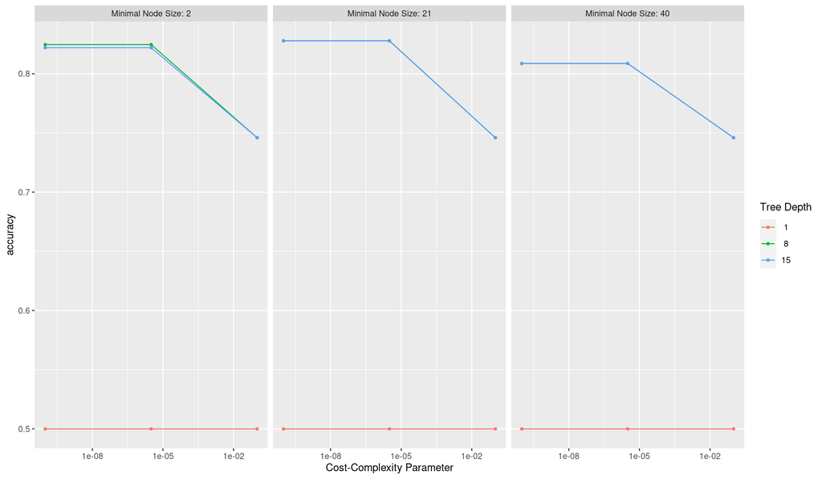

```r
metrics <- yardstick::metric_set(accuracy)
mp_start <- mp_wf %>%
  tune_grid(
    resamples = mp_cv,
    grid = start_grid,
    metrics = metrics
  ) ; beepr::beep(1)

autoplot(mp_start)
```

```r
show_best(mp_start)
```

| cost_complexity | tree_depth | min_n | .metric | .estimator | mean | n | std_err | .config |
| --- | --- | --- | --- | --- | --- | --- | --- | --- |
| 1.000000e-10 | 8 | 21 | accuracy | multiclass | 0.8278723 | 25 | 0.003486377 | Preprocessor1_Model13 |
| 3.162278e-06 | 8 | 21 | accuracy | multiclass | 0.8278723 | 25 | 0.003486377 | Preprocessor1_Model14 |
| 1.000000e-10 | 15 | 21 | accuracy | multiclass | 0.8277660 | 25 | 0.003535934 | Preprocessor1_Model16 |
| 3.162278e-06 | 15 | 21 | accuracy | multiclass | 0.8277660 | 25 | 0.003535934 | Preprocessor1_Model17 |
| 1.000000e-10 | 8 | 2 | accuracy | multiclass | 0.8246809 | 25 | 0.003146551 | Preprocessor1_Model04 |

Ahora que ya tenemos posibles valores iniciales (`tune` utilizará el mejor), pasamos a la búsqueda iterativa, en particular usando optimización bayesiana.

```r
ctrl <- tune::control_bayes(verbose = TRUE)
mp_bayesopt <-
  mp_wf %>%
  tune_bayes(
    resamples = mp_cv,
    metrics = metrics,
    initial = mp_start,
    iter = 20,
    control = ctrl
  ) ; beepr::beep(1)
```

```
## Optimizing accuracy using the expected improvement
```

```
## ── Iteration 1 ─────────────────────────────────────────────────────────────────
```

```
## i Current best:      accuracy=0.8279 (@iter 0)
```

```
## i Gaussian process model
```

```
## ✓ Gaussian process model
```

```
## i Generating 5000 candidates
```

```
## i Predicted candidates
```

```
## i cost_complexity=2.03e-08, tree_depth=11, min_n=14
```

```
## i Estimating performance
```

```
## ✓ Estimating performance
```

```
## ♥ Newest results:    accuracy=0.8365 (+/-0.00352)
```

```
## ── Iteration 2 ─────────────────────────────────────────────────────────────────
```

```
## i Current best:      accuracy=0.8365 (@iter 1)
```

```
## i Gaussian process model
```

```
## ✓ Gaussian process model
```

```
## i Generating 5000 candidates
```

```
## i Predicted candidates
```

```
## i cost_complexity=1.46e-08, tree_depth=9, min_n=14
```

```
## i Estimating performance
```

```
## ✓ Estimating performance
```

```
## ⓧ Newest results:    accuracy=0.8365 (+/-0.00352)
```

```
## ── Iteration 3 ─────────────────────────────────────────────────────────────────
```

```
## i Current best:      accuracy=0.8365 (@iter 1)
```

```
## i Gaussian process model
```

```
## ✓ Gaussian process model
```

```
## i Generating 5000 candidates
```

```
## i Predicted candidates
```

```
## i cost_complexity=5.46e-07, tree_depth=10, min_n=18
```

```
## i Estimating performance
```

```
## ✓ Estimating performance
```

```
## ⓧ Newest results:    accuracy=0.8299 (+/-0.00326)
```

```
## ── Iteration 4 ─────────────────────────────────────────────────────────────────
```

```
## i Current best:      accuracy=0.8365 (@iter 1)
```

```
## i Gaussian process model
```

```
## ✓ Gaussian process model
```

```
## i Generating 5000 candidates
```

```
## i Predicted candidates
```

```
## i cost_complexity=1.55e-08, tree_depth=14, min_n=16
```

```
## i Estimating performance
```

```
## ✓ Estimating performance
```

```
## ⓧ Newest results:    accuracy=0.833 (+/-0.00347)
```

```
## ── Iteration 5 ─────────────────────────────────────────────────────────────────
```

```
## i Current best:      accuracy=0.8365 (@iter 1)
```

```
## i Gaussian process model
```

```
## ✓ Gaussian process model
```

```
## i Generating 5000 candidates
```

```
## i Predicted candidates
```

```
## i cost_complexity=5.89e-10, tree_depth=11, min_n=19
```

```
## i Estimating performance
```

```
## ✓ Estimating performance
```

```
## ⓧ Newest results:    accuracy=0.8283 (+/-0.00333)
```

```
## ── Iteration 6 ─────────────────────────────────────────────────────────────────
```

```
## i Current best:      accuracy=0.8365 (@iter 1)
```

```
## i Gaussian process model
```

```
## ✓ Gaussian process model
```

```
## i Generating 5000 candidates
```

```
## i Predicted candidates
```

```
## i cost_complexity=2.23e-08, tree_depth=15, min_n=17
```

```
## i Estimating performance
```

```
## ✓ Estimating performance
```

```
## ⓧ Newest results:    accuracy=0.8312 (+/-0.00333)
```

```
## ── Iteration 7 ─────────────────────────────────────────────────────────────────
```

```
## i Current best:      accuracy=0.8365 (@iter 1)
```

```
## i Gaussian process model
```

```
## ✓ Gaussian process model
```

```
## i Generating 5000 candidates
```

```
## i Predicted candidates
```

```
## i cost_complexity=1.64e-07, tree_depth=12, min_n=7
```

```
## i Estimating performance
```

```
## ✓ Estimating performance
```

```
## ⓧ Newest results:    accuracy=0.8353 (+/-0.0033)
```

```
## ── Iteration 8 ─────────────────────────────────────────────────────────────────
```

```
## i Current best:      accuracy=0.8365 (@iter 1)
```

```
## i Gaussian process model
```

```
## ✓ Gaussian process model
```

```
## i Generating 5000 candidates
```

```
## i Predicted candidates
```

```
## i cost_complexity=5.52e-08, tree_depth=8, min_n=14
```

```
## i Estimating performance
```

```
## ✓ Estimating performance
```

```
## ⓧ Newest results:    accuracy=0.8363 (+/-0.00353)
```

```
## ── Iteration 9 ─────────────────────────────────────────────────────────────────
```

```
## i Current best:      accuracy=0.8365 (@iter 1)
```

```
## i Gaussian process model
```

```
## ✓ Gaussian process model
```

```
## i Generating 5000 candidates
```

```
## i Predicted candidates
```

```
## i cost_complexity=2.43e-08, tree_depth=11, min_n=5
```

```
## i Estimating performance
```

```
## ✓ Estimating performance
```

```
## ⓧ Newest results:    accuracy=0.8343 (+/-0.00294)
```

```
## ── Iteration 10 ────────────────────────────────────────────────────────────────
```

```
## i Current best:      accuracy=0.8365 (@iter 1)
```

```
## i Gaussian process model
```

```
## ✓ Gaussian process model
```

```
## i Generating 5000 candidates
```

```
## i Predicted candidates
```

```
## i cost_complexity=1.1e-07, tree_depth=13, min_n=13
```

```
## i Estimating performance
```

```
## ✓ Estimating performance
```

```
## ⓧ Newest results:    accuracy=0.8343 (+/-0.00379)
```

```
## ── Iteration 11 ────────────────────────────────────────────────────────────────
```

```
## i Current best:      accuracy=0.8365 (@iter 1)
```

```
## i Gaussian process model
```

```
## ✓ Gaussian process model
```

```
## i Generating 5000 candidates
```

```
## i Predicted candidates
```

```
## i cost_complexity=2.47e-08, tree_depth=12, min_n=12
```

```
## i Estimating performance
```

```
## ✓ Estimating performance
```

```
## ⓧ Newest results:    accuracy=0.8356 (+/-0.00386)
```

```
## ! No improvement for 10 iterations; returning current results.
```

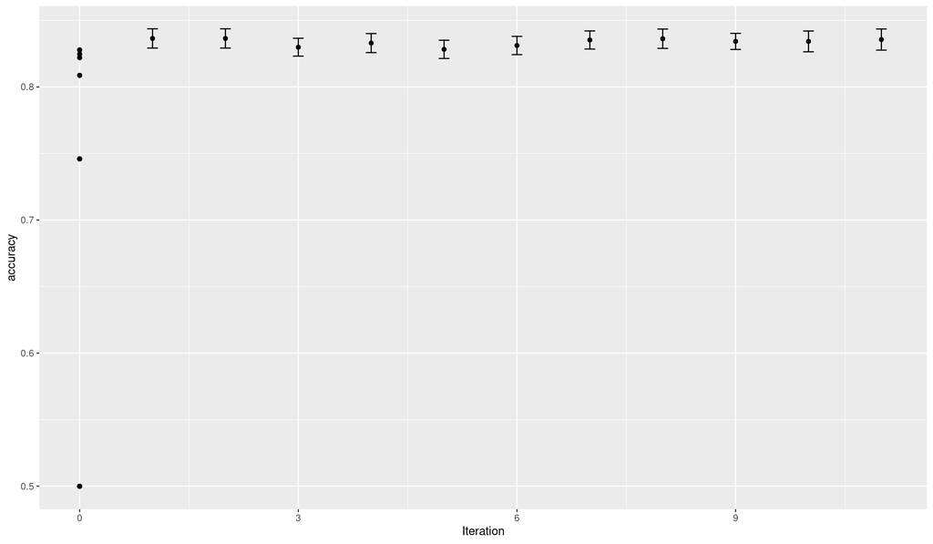

```r
# Vemos la evolución a través de las iteraciones
autoplot(mp_bayesopt, type = "performance")
```

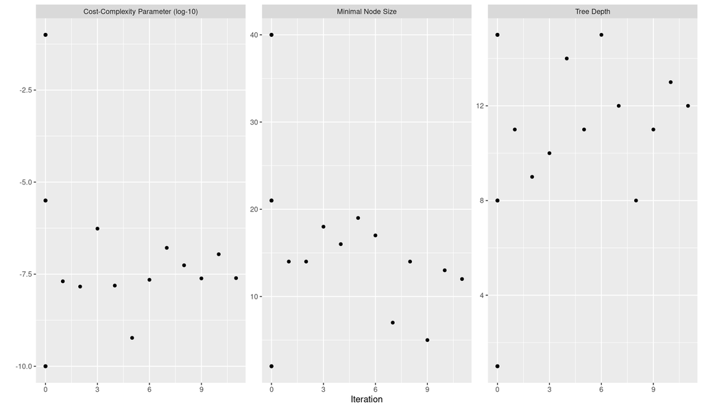

```r
autoplot(mp_bayesopt, type = "parameters")
```

```r
# Vemos los mejores valores
select_best(mp_bayesopt)
```

| cost_complexity | tree_depth | min_n | .config |
| --- | --- | --- | --- |
| 2.025578e-08 | 11 | 14 | Iter1 |

Ya teniendo los hiperparámetros óptimos, obtenemos el fit final y realizamos las predicciones en la base de test.

```r
# Obtenemos el fit final
mp_final_wf <-
  mp_wf %>%
  finalize_workflow(select_best(mp_bayesopt))
mp_final_wf
```

```
## ══ Workflow ════════════════════════════════════════════════════════════════════
## Preprocessor: Recipe
## Model: decision_tree()
##
## ── Preprocessor ────────────────────────────────────────────────────────────────
## 0 Recipe Steps
##
## ── Model ───────────────────────────────────────────────────────────────────────
## Decision Tree Model Specification (classification)
##
## Main Arguments:
##   cost_complexity = 2.02557805062548e-08
##   tree_depth = 11
##   min_n = 14
##
## Computational engine: rpart
```

```r
# Ajustamos y predecimos
mp_fit <-
  mp_final_wf %>%
  fit(mp_train)

mp_predictions <-
  mp_fit %>%
  predict(new_data = mp_test) %>%
  dplyr::bind_cols(mp_test) %>%
  dplyr::select(price_range, .pred_class)
head(mp_predictions)
```

| price_range | .pred_class |
| --- | --- |
| Low | Low |
| Very High | Very High |
| Low | Low |
| Very High | Very High |
| Very High | High |
| Medium | Medium |

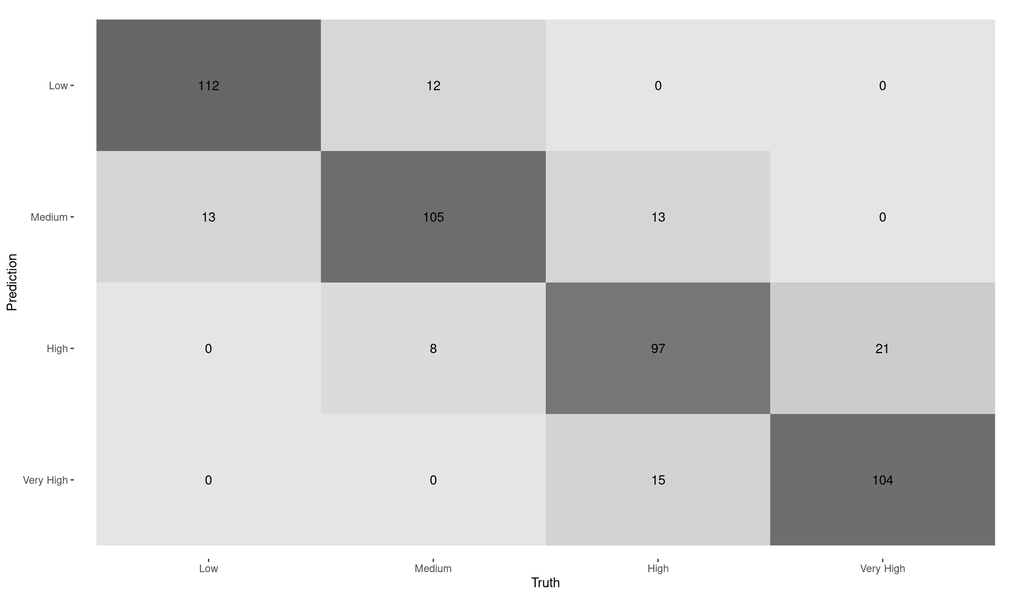

```r
# Vemos la matriz de confusión
conf_mat_tree <- conf_mat(
  data = mp_predictions,
  truth = price_range,
  estimate = .pred_class
)

autoplot(conf_mat_tree, "heatmap")
```

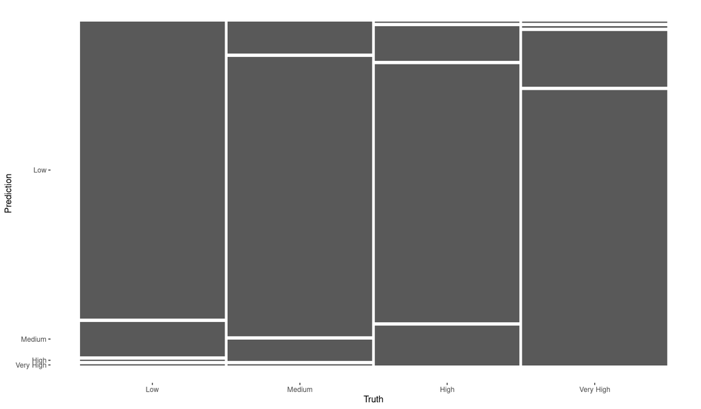

```r
autoplot(conf_mat_tree, "mosaic")
```

```r
# Vemos el valor del accuracy
acc_tree <- accuracy(
  data = mp_predictions,
  truth = price_range,
  estimate = .pred_class
)
acc_tree
```

| .metric | .estimator | .estimate |
| --- | --- | --- |
| accuracy | multiclass | 0.836 |

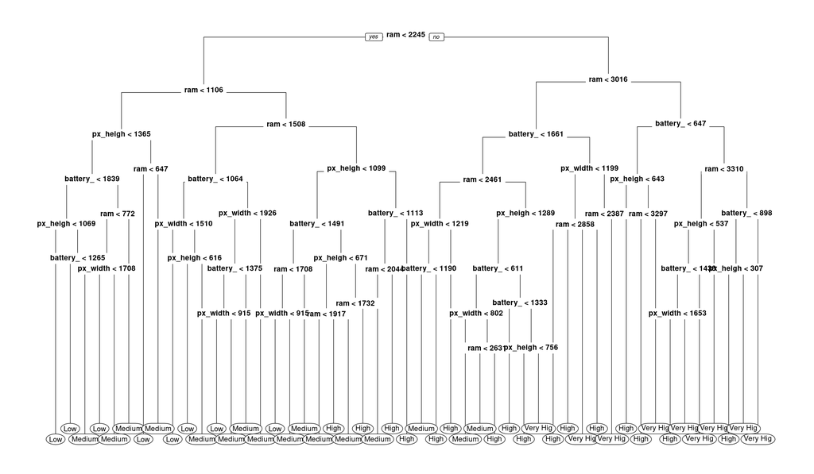

```r
# Vemos un gráfico del árbol
rpart.plot::prp(mp_fit$fit$fit$fit, type = 0, fallen.leaves = TRUE,
                tweak = 1.3, roundint = FALSE)
```

## Modelamiento: Bosque aleatorio

Por último, ajustamos también un bosque aleatorio para ver si este modelo logra mejorar el poder de predicción. En `parsnip`, el modelo se define a través de `rand_forest`, el cual por defecto utiliza la librería `ranger`.

Es importante notar que no debemos cambiar la base de entrenamiento y de test. Otra cosa importante es que los bosques aleatorios **no** consideran la poda del árbol (regulado por el parámetro de complejidad), pero se cambia por el parámetro $m$ que indica la cantidad de predictores a usar en cada división. Tampoco se considera el parámetro de profundidad, pero sí un parámetro que indica la cantidad de árboles que conforman el bosque.

```r
# 2. Especificación del modelo

mp_model_b <- parsnip::rand_forest(mtry = tune(),
                                   trees = tune(),
                                   min_n = tune()) %>%
  set_engine("ranger") %>%
  set_mode("classification")

# 3. Especificación de la receta
mp_recipe_b <- recipes::recipe(price_range ~ ., data = mp_train)

# 4. Modelo
mp_wf_b <-
  workflows::workflow() %>%
  add_model(mp_model_b) %>%
  add_recipe(mp_recipe_b)
```

### Tuning hiperparámetros

Realizamos lo mismo que con el árbol de decisión.

```r
mtry()
```

```
## # Randomly Selected Predictors (quantitative)
## Range: [1, ?]
```

```r
trees()
```

```
## # Trees (quantitative)
## Range: [1, 2000]
```

```r
min_n()
```

```
## Minimal Node Size (quantitative)
## Range: [2, 40]
```

Acá es importante notar que `mtry` no está completo aún, ya que no sabe el número total de variables predictoras.

```r
# Definimos la grilla de partida
start_grid <-
  parameters(finalize(mtry(), x = select(mp_train, -price_range)),
             trees(),
             min_n()) %>%
  grid_regular()
start_grid
```

| mtry | trees | min_n |
| --- | --- | --- |
| 1 | 1 | 2 |
| 10 | 1 | 2 |
| 20 | 1 | 2 |
| 1 | 1000 | 2 |
| 10 | 1000 | 2 |
| 20 | 1000 | 2 |
| 1 | 2000 | 2 |
| 10 | 2000 | 2 |
| 20 | 2000 | 2 |
| 1 | 1 | 21 |

[output cut: 17 more lines]

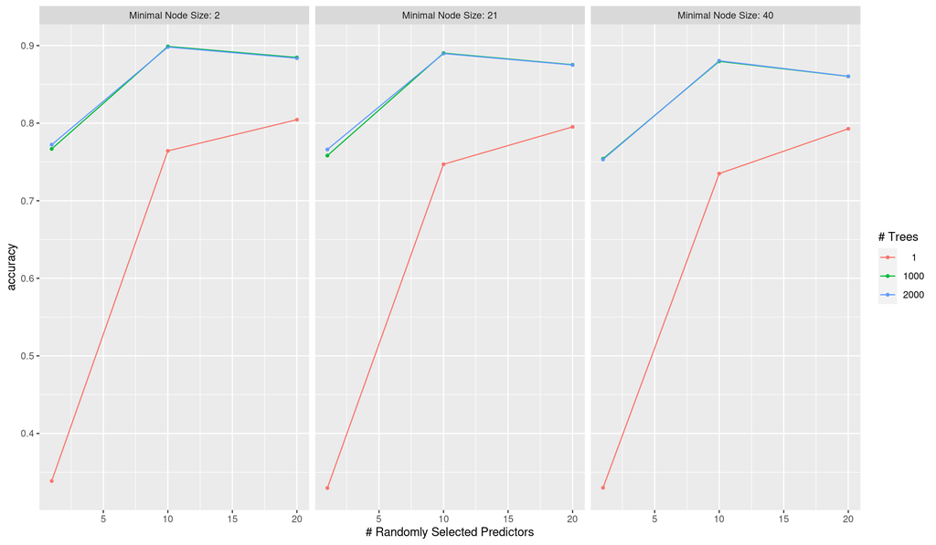

```r
metrics <- yardstick::metric_set(accuracy)
mp_start_b <- mp_wf_b %>%
  tune_grid(
    resamples = mp_cv,
    grid = start_grid,
    metrics = metrics
  ) ; beepr::beep(1)

autoplot(mp_start_b)
```

```r
show_best(mp_start_b)
```

| mtry | trees | min_n | .metric | .estimator | mean | n | std_err | .config |
| --- | --- | --- | --- | --- | --- | --- | --- | --- |
| 10 | 1000 | 2 | accuracy | multiclass | 0.8989362 | 25 | 0.003067171 | Preprocessor1_Model05 |
| 10 | 2000 | 2 | accuracy | multiclass | 0.8980851 | 25 | 0.003299445 | Preprocessor1_Model08 |
| 10 | 1000 | 21 | accuracy | multiclass | 0.8903191 | 25 | 0.003485565 | Preprocessor1_Model14 |
| 10 | 2000 | 21 | accuracy | multiclass | 0.8896809 | 25 | 0.003634060 | Preprocessor1_Model17 |
| 20 | 1000 | 2 | accuracy | multiclass | 0.8846809 | 25 | 0.003339081 | Preprocessor1_Model06 |

Ya teniendo los valores iniciales, pasamos a la optimización bayesiana.

```r
ctrl <- tune::control_bayes(verbose = TRUE)
mp_bayesopt_b <-
  mp_wf_b %>%
  tune_bayes(
    resamples = mp_cv,
    metrics = metrics,
    initial = mp_start_b,
    param_info = parameters(finalize(mtry(), x = select(mp_train, -price_range)),
                            trees(),
                            min_n()),
    iter = 10,
    control = ctrl
  ) ; beepr::beep(1)
```

```
## Optimizing accuracy using the expected improvement
```

```
## ── Iteration 1 ─────────────────────────────────────────────────────────────────
```

```
## i Current best:      accuracy=0.8989 (@iter 0)
```

```
## i Gaussian process model
```

```
## ✓ Gaussian process model
```

```
## i Generating 4999 candidates
```

```
## i Predicted candidates
```

```
## i mtry=14, trees=1526, min_n=2
```

```
## i Estimating performance
```

```
## ✓ Estimating performance
```

```
## ⓧ Newest results:    accuracy=0.8945 (+/-0.00313)
```

```
## ── Iteration 2 ─────────────────────────────────────────────────────────────────
```

```
## i Current best:      accuracy=0.8989 (@iter 0)
```

```
## i Gaussian process model
```

```
## ✓ Gaussian process model
```

```
## i Generating 4992 candidates
```

```
## i Predicted candidates
```

```
## i mtry=15, trees=600, min_n=2
```

```
## i Estimating performance
```

```
## ✓ Estimating performance
```

```
## ⓧ Newest results:    accuracy=0.8923 (+/-0.00294)
```

```
## ── Iteration 3 ─────────────────────────────────────────────────────────────────
```

```
## i Current best:      accuracy=0.8989 (@iter 0)
```

```
## i Gaussian process model
```

```
## ✓ Gaussian process model
```

```
## i Generating 4995 candidates
```

```
## i Predicted candidates
```

```
## i mtry=8, trees=1512, min_n=4
```

```
## i Estimating performance
```

```
## ✓ Estimating performance
```

```
## ♥ Newest results:    accuracy=0.8993 (+/-0.00294)
```

```
## ── Iteration 4 ─────────────────────────────────────────────────────────────────
```

```
## i Current best:      accuracy=0.8993 (@iter 3)
```

```
## i Gaussian process model
```

```
## ✓ Gaussian process model
```

```
## i Generating 4994 candidates
```

```
## i Predicted candidates
```

```
## i mtry=13, trees=1990, min_n=4
```

```
## i Estimating performance
```

```
## ✓ Estimating performance
```

```
## ⓧ Newest results:    accuracy=0.8953 (+/-0.00308)
```

```
## ── Iteration 5 ─────────────────────────────────────────────────────────────────
```

```
## i Current best:      accuracy=0.8993 (@iter 3)
```

```
## i Gaussian process model
```

```
## ✓ Gaussian process model
```

```
## i Generating 4997 candidates
```

```
## i Predicted candidates
```

```
## i mtry=10, trees=1348, min_n=2
```

```
## i Estimating performance
```

```
## ✓ Estimating performance
```

```
## ⓧ Newest results:    accuracy=0.8967 (+/-0.00288)
```

```
## ── Iteration 6 ─────────────────────────────────────────────────────────────────
```

```
## i Current best:      accuracy=0.8993 (@iter 3)
```

```
## i Gaussian process model
```

```
## ✓ Gaussian process model
```

```
## i Generating 4998 candidates
```

```
## i Predicted candidates
```

```
## i mtry=20, trees=1499, min_n=3
```

```
## i Estimating performance
```

```
## ✓ Estimating performance
```

```
## ⓧ Newest results:    accuracy=0.8841 (+/-0.00337)
```

```
## ── Iteration 7 ─────────────────────────────────────────────────────────────────
```

```
## i Current best:      accuracy=0.8993 (@iter 3)
```

```
## i Gaussian process model
```

```
## ✓ Gaussian process model
```

```
## i Generating 4997 candidates
```

```
## i Predicted candidates
```

```
## i mtry=14, trees=1002, min_n=3
```

```
## i Estimating performance
```

```
## ✓ Estimating performance
```

```
## ⓧ Newest results:    accuracy=0.8939 (+/-0.00309)
```

```
## ── Iteration 8 ─────────────────────────────────────────────────────────────────
```

```
## i Current best:      accuracy=0.8993 (@iter 3)
```

```
## i Gaussian process model
```

```
## ✓ Gaussian process model
```

```
## i Generating 4997 candidates
```

```
## i Predicted candidates
```

```
## i mtry=11, trees=1759, min_n=3
```

```
## i Estimating performance
```

```
## ✓ Estimating performance
```

```
## ⓧ Newest results:    accuracy=0.8979 (+/-0.00301)
```

```
## ── Iteration 9 ─────────────────────────────────────────────────────────────────
```

```
## i Current best:      accuracy=0.8993 (@iter 3)
```

```
## i Gaussian process model
```

```
## ✓ Gaussian process model
```

```
## i Generating 4999 candidates
```

```
## i Predicted candidates
```

```
## i mtry=17, trees=1813, min_n=3
```

```
## i Estimating performance
```

```
## ✓ Estimating performance
```

```
## ⓧ Newest results:    accuracy=0.8899 (+/-0.00313)
```

```
## ── Iteration 10 ────────────────────────────────────────────────────────────────
```

```
## i Current best:      accuracy=0.8993 (@iter 3)
```

```
## i Gaussian process model
```

```
## ✓ Gaussian process model
```

```
## i Generating 4997 candidates
```

```
## i Predicted candidates
```

```
## i mtry=9, trees=1574, min_n=3
```

```
## i Estimating performance
```

```
## ✓ Estimating performance
```

```
## ⓧ Newest results:    accuracy=0.8979 (+/-0.00312)
```

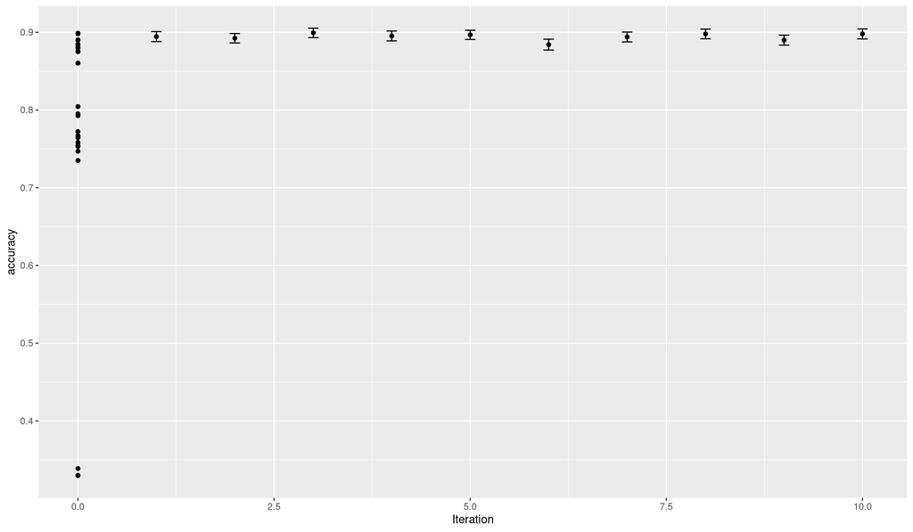

```r
autoplot(mp_bayesopt_b, type = "performance")
```

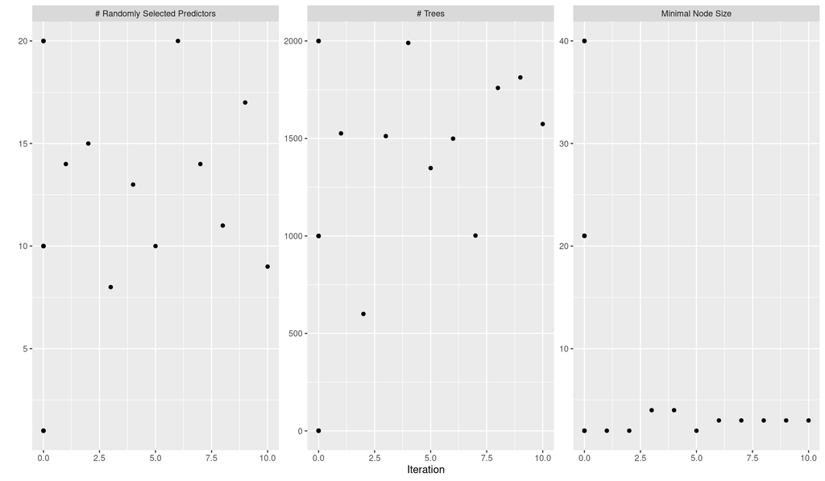

```r
autoplot(mp_bayesopt_b, type = "parameters")
```

```r
select_best(mp_bayesopt_b)
```

| mtry | trees | min_n | .config |
| --- | --- | --- | --- |
| 8 | 1512 | 4 | Iter3 |

Ya teniendo el óptimo, ajustamos el modelo final.

```r
mp_final_wf_b <-
  mp_wf_b %>%
  finalize_workflow(select_best(mp_bayesopt_b))
mp_final_wf_b
```

```
## ══ Workflow ════════════════════════════════════════════════════════════════════
## Preprocessor: Recipe
## Model: rand_forest()
##
## ── Preprocessor ────────────────────────────────────────────────────────────────
## 0 Recipe Steps
##
## ── Model ───────────────────────────────────────────────────────────────────────
## Random Forest Model Specification (classification)
##
## Main Arguments:
##   mtry = 8
##   trees = 1512
##   min_n = 4
##
## Computational engine: ranger
```

```r
# Ajustamos y predecimos
mp_fit_b <-
  mp_final_wf_b %>%
  fit(mp_train)

mp_predictions_b <-
  mp_fit_b %>%
  predict(new_data = mp_test) %>%
  dplyr::bind_cols(mp_test) %>%
  dplyr::select(price_range, .pred_class)
head(mp_predictions)
```

| price_range | .pred_class |
| --- | --- |
| Low | Low |
| Very High | Very High |
| Low | Low |
| Very High | Very High |
| Very High | High |
| Medium | Medium |

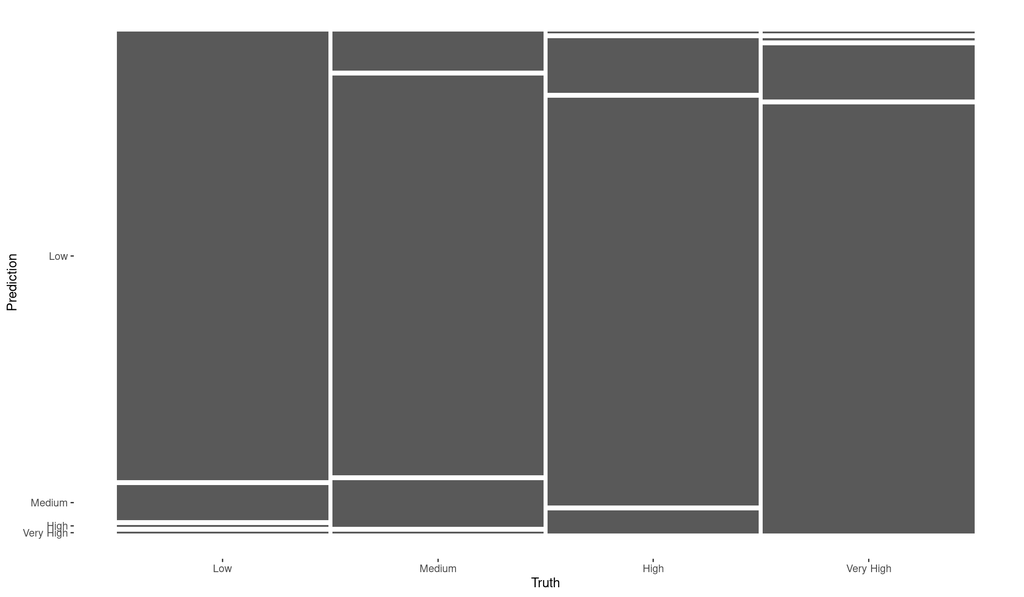

```r
conf_mat_tree_b <- conf_mat(
  data = mp_predictions_b,
  truth = price_range,
  estimate = .pred_class
)

autoplot(conf_mat_tree_b, "mosaic")
```

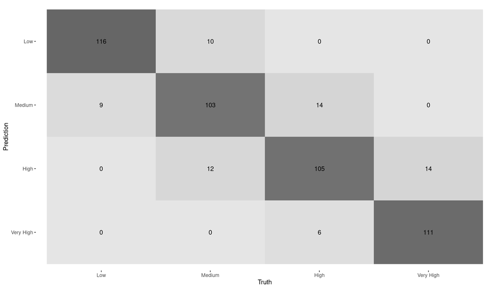

```r
autoplot(conf_mat_tree_b, "heatmap")
```

```r
# Vemos el valor del accuracy
acc_rf <- accuracy(
  data = mp_predictions_b,
  truth = price_range,
  estimate = .pred_class
)
acc_rf
```

| .metric | .estimator | .estimate |
| --- | --- | --- |
| accuracy | multiclass | 0.87 |

```r
acc_tree
```

| .metric | .estimator | .estimate |
| --- | --- | --- |
| accuracy | multiclass | 0.836 |

Vemos que el modelo de Bosque Aleatorio obtuvo mejores resultados (considerando accuracy)